# R Basics

Andreas Blombach, Philipp Heinrich

08.11.2022

## Preliminary remarks

As you may have noticed, there is quite a bit of text in this script. This text is designed to help you understand the actual code – the lines which are not preceded by a hash (#). You can directly execute the code (we’ll get to that in a minute). A better idea, however, might be to type it in again yourself at the bottom of the console or to copy it into your own script (with your own modifications and additions, if you like!) – you’ll probably learn more this way!

If you’re wondering why most comments in this script are followed by an apostrophe (and why there is some weird stuff at the beginning), that’s because RStudio can be used to create specially formatted HTML files in conjunction with the “knitr” and “rmarkdown” packages.

Headings, text formatting, lists, etc. are marked according to the specifications of R Markdown (http://rmarkdown.rstudio.com/lesson-1.html).

And since we’re already referencing URLs: A helpful “cheatsheet” for R can be found at: https://github.com/rstudio/cheatsheets/blob/master/base-r.pdf

## R as a calculator

Try entering some basic calculations!

```r
1 + 1
```

```
## [1] 2
```

```r
2 ** 10
```

```
## [1] 1024
```

```r
8 %/% 3
```

```
## [1] 2
```

## Objects

To work with data, we use *objects*. Objects are stored in the current *environment*. Single values, data structures and functions are all objects.

To access an object, it needs a name. This name should start with a letter (after that, you’re free to use whatever combination of letters, numbers and some special characters (like dots or underscores) you like).

```r
my_first_object <- 42 # the arrow assigns the value 42 to my_first_object
my_first_object = 42  # or just use the equality sign
```

https://stackoverflow.com/questions/1741820/what-are-the-differences-between-and-assignment-operators-in-r

Execute the line above by placing the cursor somewhere in it and pressing CTRL+Enter (or by clicking “Run” in RStudio).

Notice that it will now appear in the environment.

You can now access the object’s value by entering its name:

```r
my_first_object
```

```
## [1] 42
```

Create a few more objects. You can also assign the value of an existing object to a new object (thereby copying it), do calculations with objects and assign the result of these to objects. (What happens when you multiply an object by itself and assign the result to the same object?)

You can also see the objects in the current environment by executing this function:

```r
ls()
```

```
## [1] "my_first_object"
```

To get rid of an object, use `rm()`:

```r
rm(my_first_object)
```

To get rid of *all* objects in the current environment:

```r
rm(list = ls())
```

## Functions

Functions like these can be recognised by the round brackets.

A function has a name (the characters before the brackets) and may have different arguments (between the brackets), separated by commas. Arguments may be either optional or obligatory.

For example, the following are well-known functions from highschool:

```r
exp(1)
```

```
## [1] 2.718282
```

```r
log(1)
```

```
## [1] 0
```

```r
exp(log(1))
```

```
## [1] 1
```

```r
log(2, base = 2)
```

```
## [1] 1
```

```r
log2(2)
```

```
## [1] 1
```

The following function produces five random numbers between 1 and 10:

```r
sample(1:10, 5)
```

```
## [1]  2 10  3  5  1
```

To take a sample with replacement (allowing the same number to be drawn multiple times), we can specify the optional argument `replace`:

```r
sample(1:10, 11, replace = TRUE)
```

```
##  [1]  1  7  2 10  3  6  5  7 10  3  4
```

## Built-in documentation

To look up what a function does and how it works, you can access the built-in documentation by typing `?` followed by the function’s name: `?sample`

```r
?hist
```

```
## starte den http Server für die Hilfe fertig
```

Alternatively, you can use the `help` function:

```r
help("seq")
help.search("barplot")
?help.search

help.start()  # searchable HTML documentation
```

```
## Wenn nichts passiert, sollten Sie 'http://127.0.0.1:10409/doc/html/index.html' selbst öffnen
```

```r
# or use GUI menus to access & search documentation
```

If you enter a function’s arguments in the exact same order as seen in its documentation, you don’t need to specify the names of its arguments. If you do specify them, however, you are free to enter them in any order you want:

```r
sample(replace = TRUE, size = 5, x = 1:100)
```

```
## [1] 44 52 90 74 29
```

## Installing and loading packages

R already provides quite a lot of functions, but sooner or later, you’ll need some more …

A package is a collection of functions and/or data sets, usually for a certain range of applications (e.g. plotting, linear mixed-effects models, corpus analysis, …).

When packages are installed, they are stored locally (e.g. on a hard drive). The set of installed packages can be thought of as a library: if you need a certain package in your current session, you can check it out (thus activating it).

To install a package (or several, by providing a vector of package names):

- `install.packages("name_of_package")`
- `install.packages(c("package1", "package2", "package3"))`

By default, dependencies are also installed (= packages which are required for your new package to work properly).

To activate an installed package:

- `library("name_of_package")`
- `library(name_of_package)`

(For whatever reason, quotation marks are optional in this case.)

You can also use RStudio to install, update, activate and deactivate packages.

A much more extensive tutorial (useful even for advanced users): https://www.datacamp.com/community/tutorials/r-packages-guide

We’ll need some packages later, so let’s activate them – install them on your local machine, if necessary:

```r
library(tidyverse)
library(readxl)
library(data.table)
```

The Tidyverse is actually a whole collection of packages that share a certain a certain approach and underlying philosophy. The core packages (see https://www.tidyverse.org/packages/) are:

- ggplot2 (graphics)
- dplyr (data manipulation)
- tidyr (tidying and pivoting data)
- readr (importing data)
- purrr (functional programming)
- tibble (an alternative to R’s native data.frame)
- stringr (string manipulation)
- forcats (handling factors, i.e. categorial variables)

Some Tidyverse approaches to working and programming in R can be considered as a dialect of R. There are therefore often different ways of doing something. You can find nice comparisons of base R and the Tidyverse (and `data.table` as well) online, for example here: https://wetlandscapes.com/blog/a-comparison-of-r-dialects/

## Logical Operators

To check if values are equal, if one is greater than another etc., we need logical operators.

```r
a <- 5
b <- 2
```

Are a and b equal?

```r
a == b
```

```
## [1] FALSE
```

Is a greater than b?

```r
a > b
```

```
## [1] TRUE
```

Also:

```r
a >= b # greater or equal
```

```
## [1] TRUE
```

```r
a < b # smaller
```

```
## [1] FALSE
```

```r
a <= b # smaller or equal
```

```
## [1] FALSE
```

```r
a != b # not equal
```

```
## [1] TRUE
```

On its own, the exclamation mark (“not”) negates an expression

```r
!(a < b) # returns TRUE if the following expression is FALSE
```

```
## [1] TRUE
```

We can use `&` (AND) and `|` (OR) to combine conditions:

```r
a > b & a != b # TRUE if both sides are TRUE
```

```
## [1] TRUE
```

```r
a < b | a > b # TRUE if at least one of the sides is TRUE
```

```
## [1] TRUE
```

If we want to know if only one of both sides is TRUE, we need XOR (excluding OR):

```r
xor(a < b, a > b) # TRUE
```

```
## [1] TRUE
```

```r
xor(a > b, a != b) # FALSE (since both conditions are TRUE)
```

```
## [1] FALSE
```

Side note: There’s also `&&` and `||` which behave somewhat differently. Can you figure it out?

```r
((-2:2) >= 0) & ((-3:1) >= 0)
```

```
## [1] FALSE FALSE FALSE  TRUE  TRUE
```

```r
((-2:2) >= 0) && ((-3:1) >= 0)
```

```
## [1] FALSE
```

## Data types

There are lots of types of data in R. Luckily, we won’t need all of them.

These are the most important basic types:

- numbers (integers and doubles)
- logical values (TRUE and FALSE)
- characters (= strings)

(Use `typeof()` to determine the basic type of objects.)

Data structures:

- vectors
- factors (ordered and unordered)
- matrices
- data sets (data.frame, tibble and data.table)
- lists

## Vectors

Probably the most important data structure in R, a vector contains elements of the same basic type (for different types, you’ll need lists). You can use the in-built function `c()` to concatenate several single objects to a vector.

```r
test_vector <- c(3, 4.6, 64, 42)
test_vector
```

```
## [1]  3.0  4.6 64.0 42.0
```

An easy way to create vectors of natural numbers is the “:” notation already used above:

```r
1:10
```

```
##  [1]  1  2  3  4  5  6  7  8  9 10
```

Vectors of characters/strings or logical values are also possible:

```r
strings <- c("colourless", "green", "ideas")
strings
```

```
## [1] "colourless" "green"      "ideas"
```

```r
logicals <- c(TRUE, FALSE, TRUE, TRUE, FALSE)
logicals
```

```
## [1]  TRUE FALSE  TRUE  TRUE FALSE
```

Vectors contain elements of the same type!

```r
new_test_vector <- c(1, "zwei", 3)
new_test_vector
```

```
## [1] "1"    "zwei" "3"
```

```r
typeof(new_test_vector)  # the numeric values were coerced to characters!
```

```
## [1] "character"
```

```r
rm(new_test_vector)
```

To get the number of elements in a vector, use `length()`:

```r
length(test_vector)
```

```
## [1] 4
```

Note that `length()` might not give you what you expected:

```r
length("a character")  # this is a single object, a.k.a. "atomic vector"
```

```
## [1] 1
```

We can use square brackets to access elements of a vector:

```r
test_vector[1]
```

```
## [1] 3
```

```r
test_vector[2]
```

```
## [1] 4.6
```

```r
strings[2]
```

```
## [1] "green"
```

We can also use vectors of numbers to access several elements:

```r
test_vector[1:3] # elements 1-3
```

```
## [1]  3.0  4.6 64.0
```

```r
logicals[2:4]
```

```
## [1] FALSE  TRUE  TRUE
```

```r
strings[c(1, 3)]
```

```
## [1] "colourless" "ideas"
```

Vectors can be part of new vectors:

```r
test_vector2 <- c(48, 120, 5, 32)
new_vector <- c(test_vector, test_vector2); new_vector
```

```
## [1]   3.0   4.6  64.0  42.0  48.0 120.0   5.0  32.0
```

To sort a vector, use `sort()`:

```r
sort(new_vector)
```

```
## [1]   3.0   4.6   5.0  32.0  42.0  48.0  64.0 120.0
```

```r
sort(new_vector, decreasing = TRUE)
```

```
## [1] 120.0  64.0  48.0  42.0  32.0   5.0   4.6   3.0
```

Mathematical operators and many functions are vectorised which means that when applied to a vector, you get a vector in return:

```r
new_vector + 2 # every element + 2
```

```
## [1]   5.0   6.6  66.0  44.0  50.0 122.0   7.0  34.0
```

```r
new_vector * 3 # every element multiplied by 3
```

```
## [1]   9.0  13.8 192.0 126.0 144.0 360.0  15.0  96.0
```

```r
sqrt(new_vector) # square root
```

```
## [1]  1.732051  2.144761  8.000000  6.480741  6.928203 10.954451  2.236068
## [8]  5.656854
```

```r
round(new_vector)
```

```
## [1]   3   5  64  42  48 120   5  32
```

```r
round(new_vector, 1) # optional second argument: number of decimal places
```

```
## [1]   3.0   4.6  64.0  42.0  48.0 120.0   5.0  32.0
```

R provides some useful methods to search inside of vectors:

Use `%in%` to check if a vector contains a certain value (if you’re dealing with large character vectors, `%chin%` from the `data.table` package is faster):

```r
48 %in% new_vector
```

```
## [1] TRUE
```

`which()` returns the position(!) of elements that meet your conditions (by using logical operators, see above):

```r
which(new_vector == 42)
```

```
## [1] 4
```

```r
which(new_vector > 40)
```

```
## [1] 3 4 5 6
```

Since this is a vector itself, you can use it to access the elements of the original vector by their position:

```r
new_vector[which(new_vector > 40)]
```

```
## [1]  64  42  48 120
```

But this might be a little easier:

```r
new_vector[new_vector > 40]
```

```
## [1]  64  42  48 120
```

You can also combine conditions:

```r
new_vector[new_vector > 40 & new_vector < 50]
```

```
## [1] 42 48
```

## Plotting

Base R offers basic but efficient plotting.

```r
x <- 1:100
y <- 2^x
```

You can either plot values of a vector against its index:

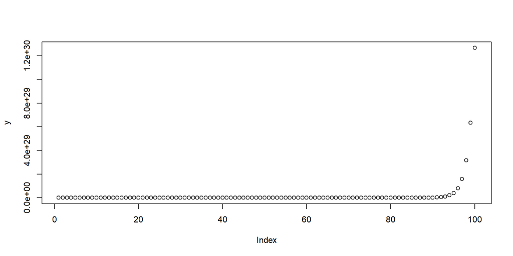

```r
plot(y)
```

… or use two vectors to plot against one another

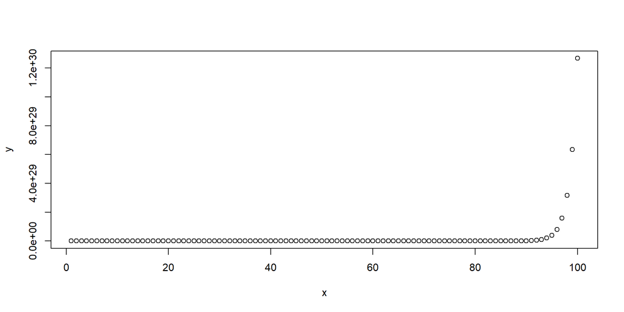

```r
plot(x, y)  # in this case equivalent to the above
```

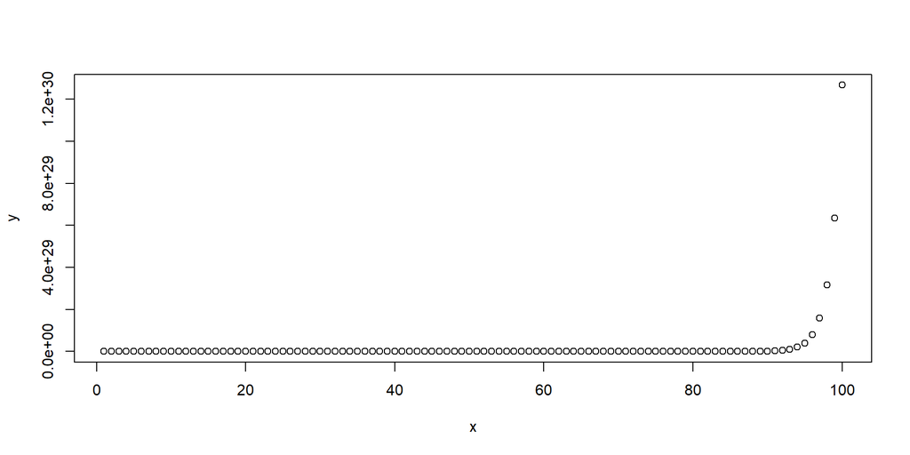

```r
plot(y ~ x) # ditto
```

The basic plot function has several helpful parameters, e.g. logarithmic scaling:

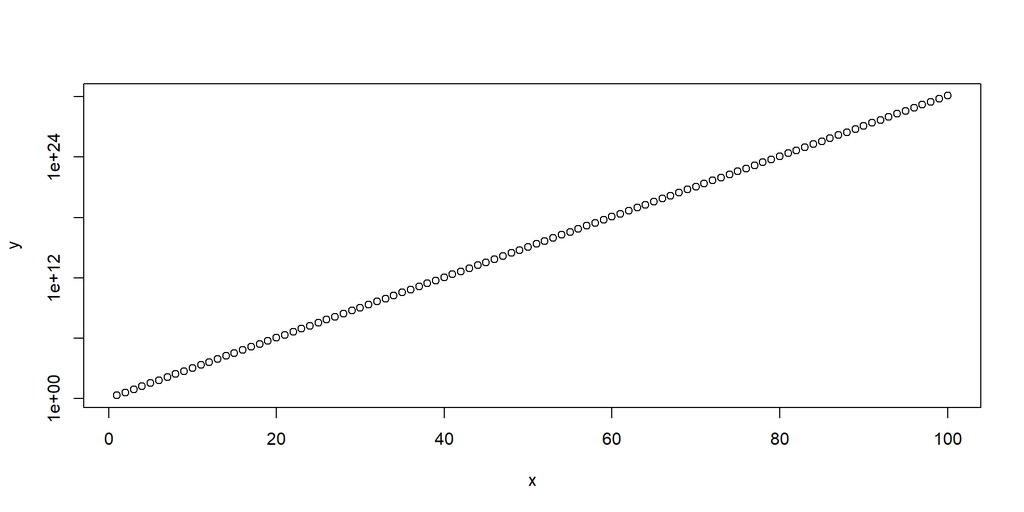

```r
plot(x, y, log = "y")
```

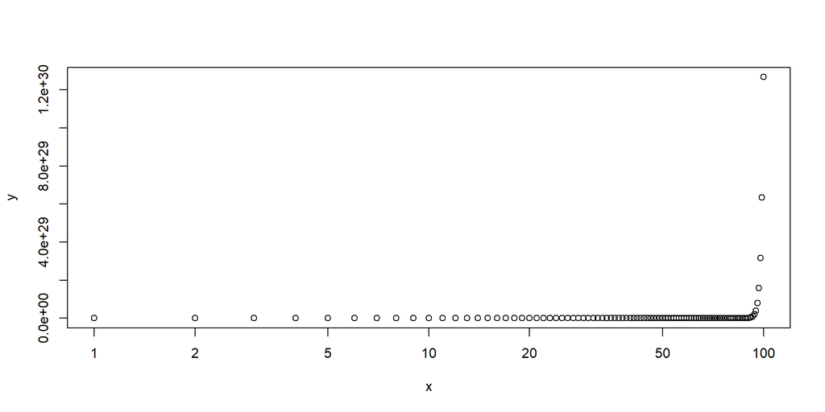

```r
plot(x, y, log = "x")
```

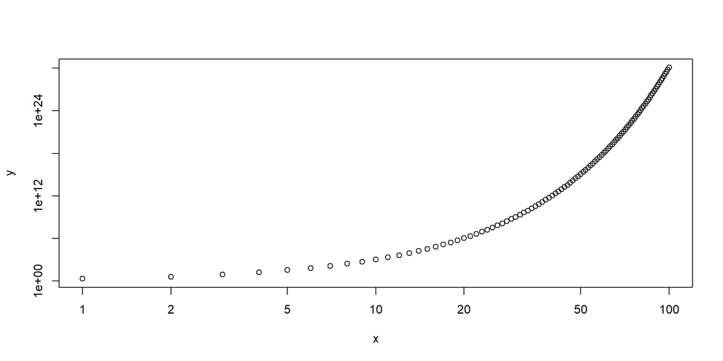

```r
plot(x, y, log = "xy")
```

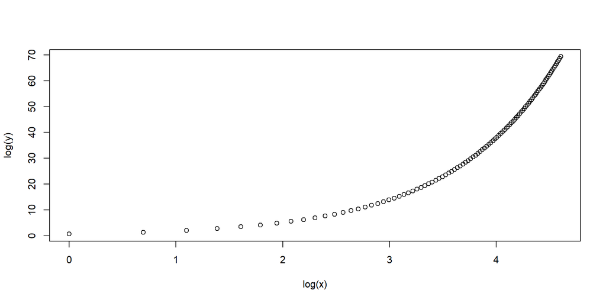

```r
plot(log(x), log(y))  # what's the difference?
```

You can also choose different types of plots:

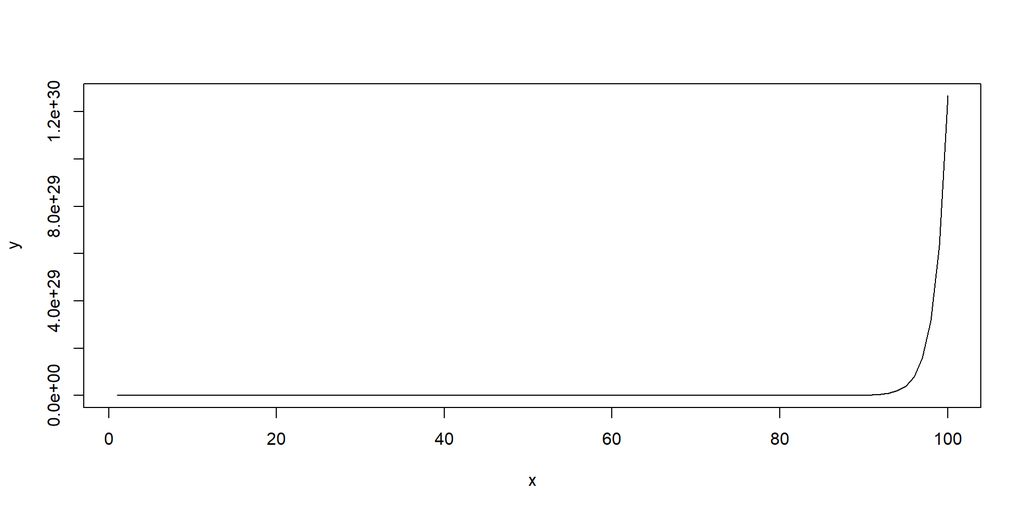

```r
plot(x, y, type = "l")
```

There are many packages to create high-quality plots, among them `ggplot2` (probably the most popular), `plotly` and `lattice`. You can also create interactive visualisations using Shiny (https://shiny.rstudio.com/). Don’t worry, we will explore all this in another session!